# Characterizing Forest Structure and Its Impact on Airtanker Drop Penetration Using Airborne Laser Scanning

Poster prepared and presented by Daniel Lowe

2025-10-06

This poster was presented at the Canadian Institute of Forestry National Conference in Thunder Bay, Ontario, in October 2025.

Contact: Daniel Lowe, University of Toronto, dz.lowe@mail.utoronto.ca

[figure not shown]

## Figures

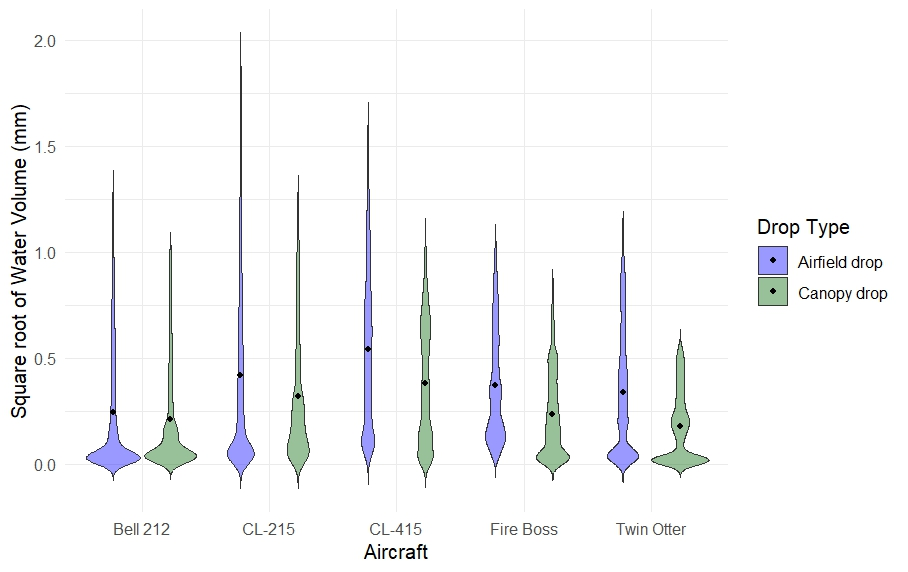

Figure 1: The distribution of water delivered (millimeters) by each aircraft in an average open field drop (blue) compared to the canopy site (green). The average (mean) amount of water delivered is represented by the back dot. Water volumes were square rooted to so visually emphasize the variability in volume across aircraft and study sites.

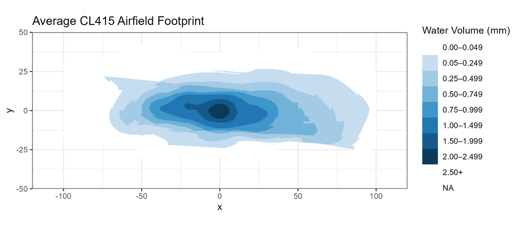

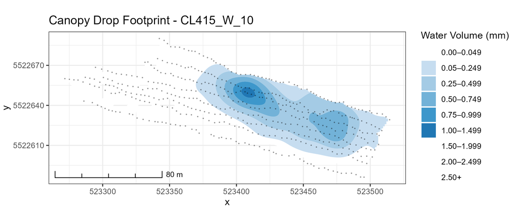

Figure 2: Interpolations comparing the average, CL415 drop in open-field conditions (n=7, top), with a CL415 drop in the canopy site (bottom).

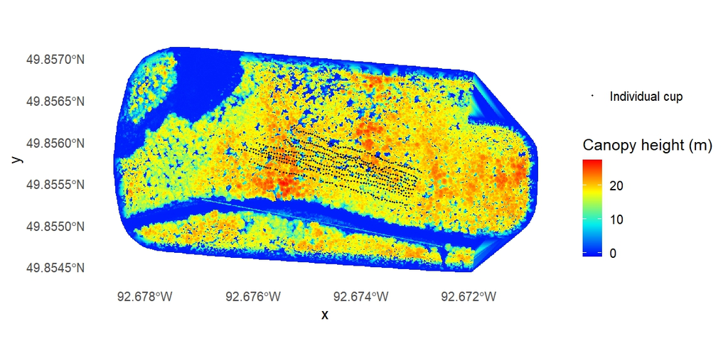

Figure 3: An aerial LiDAR-derived canopy height model of the jack pine study site in Dryden, Ontario. Black points represent each cup from the ‘cup and grid’ method inventoried with precision GPS during field work.

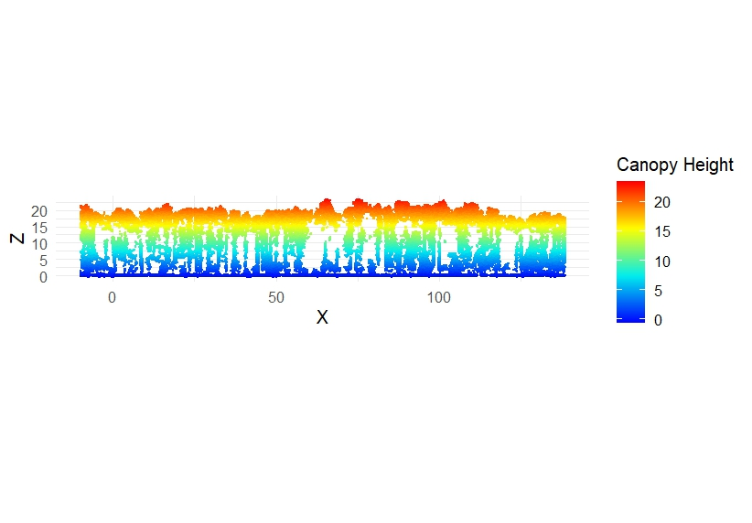

Figure 4: A latitudinal transect from the cup grid showing subcanopy structure and canopy height derived from the point cloud.

## Selected Publications

McFayden, C. B., et al. (2023). Reference guide to the drop effectiveness of skimmer and rotary wing airtankers (Information Report GLC-X-35). Natural Resources Canada, Great Lakes Forestry Centre.

Wheatley, M., Cotton-Gagnon, A., Boucher, J., Wotton, B. M., McFayden, C. B., Jurko, N., & Robinson, J. (2023). Exploring the impact of airtanker drops on in-stand temperature and relative humidity. International Journal of Wildland Fire, 32(8), 1269–1276. https://doi.org/10.1071/WF22218